# Verification of chocolate-poop preference effect (Balcetis & Dunning, 2010, study 3b pretest)

Ian Hussey

04 December, 2024

# Dependencies

```r
library(tidyverse)
library(knitr)
library(kableExtra)
library(scrutiny)
library(effectsize)
library(janitor)
```

# Original results

Balcetis & Dunning (2010) Study 3b pretest:

“In a pretest, we confirmed that chocolates were more desirable than feces. A separate group of participants (n = 20) rated how appealing, positive, likeable, attractive, and interesting both objects were. It should come as no surprise that averages across these qualities indicated that the chocolates (M = 5.5) were more desirable than the feces (M = 2.1), paired t(19) = 17.44, p_rep =.99, p ≤.001, d = 4.52.”

# 95% CIs on reported Cohen’s $d$

Original result did not report confidence intervals, so let’s add them.

We’ll treat the Cohen’s $d$ as a between-subjects Cohen’s $d_s$. There are alternatives but we won’t try to explore them all.

```r
calculate_ci_cohens_d <- function(d, n1, n2, conf.level = 0.95) {
  # calculate the standard error of Cohen's d
  se_d <- sqrt((n1 + n2) / (n1 * n2) + d^2 / (2 * (n1 + n2)))

  # degrees of freedom
  df <- n1 + n2 - 2

  # critical value from the t-distribution
  alpha <- 1 - conf.level
  t_crit <- qt(1 - alpha/2, df)

  # confidence interval
  ci_lower <- d - t_crit * se_d
  ci_upper <- d + t_crit * se_d

  return(c(ci_lower, ci_upper))
}

d_value <- 4.52
n1 <- n2 <- 20

calculate_ci_cohens_d(d_value, n1, n2) |>
  round_half_up(2)
```

```
## [1] 3.31 5.73
```

- Because of the very small sample size, there is a lot of uncertainty around the estimate, even assuming its correct.

# GRIM test applied to reported means

## N items = 5

Article states: “participants (n = 20) rated how appealing, positive, likeable, attractive, and interesting both objects were”

```r
min_decimals <- function(x, digits = 2) {
  sprintf(paste0("%.", digits, "f"), x)
}

  summary_statistics <-
  tibble(
    label = c("chocolate", "feces"),
    mean  = c(5.5,         2.1),
    #sd    = c(XXX,        XXX),  # not reported in paper
    n     = c(20,          20),
    items = c(5,           5)
  ) |>
  mutate(x = as.character(min_decimals(mean)))

# apply GRIM test
grim_results <-
  summary_statistics |>
  grim_map()

# print table
grim_results |>
  select(label, mean, consistency) |>
  knitr::kable() |>
  kableExtra::kable_classic(full_width = FALSE)
```

| label | mean | consistency |
| --- | --- | --- |
| chocolate | 5.5 | TRUE |
| feces | 2.1 | TRUE |

```r
# # plot
# grim_results |>
#   grim_plot()
```

- Means are GRIM consistent, no errors detected.

## N items = 14

Materials acquired from authors list 14 items in the scale.

NB this will always find it to be grim consistent as N participants * N items > 100.

```r
min_decimals <- function(x, digits = 2) {
  sprintf(paste0("%.", digits, "f"), x)
}

  summary_statistics <-
  tibble(
    label = c("chocolate", "feces"),
    mean  = c(5.5,         2.1),
    #sd    = c(XXX,        XXX),  # not reported in paper
    n     = c(20,          20),
    items = c(14,          14)
  ) |>
  mutate(x = as.character(min_decimals(mean)))

# apply GRIM test
grim_results <-
  summary_statistics |>
  grim_map()

# print table
grim_results |>
  select(label, mean, consistency) |>
  knitr::kable() |>
  kableExtra::kable_classic(full_width = FALSE)
```

| label | mean | consistency |
| --- | --- | --- |
| chocolate | 5.5 | TRUE |
| feces | 2.1 | TRUE |

```r
# # plot
# grim_results |>
#   grim_plot()
```

- Means can’t be assessed using GRIM

# Reproduce Cohen’s *d* from reported t-test

Reported result: “paired t(19) = 17.44 … d = 4.52”

## Assume paired Student’s *t*-test

### Reported

```r
unrounded_t_value <-
  scrutiny::unround("17.44", rounding = "up_or_down", threshold = 5) |>
  select(reported = x, lower, upper) |>
  mutate(reported = as.numeric(reported))

t_to_d(t = unrounded_t_value$reported, df_error = 19, paired = TRUE, ci = 0.95, alternative = "two.sided") |>
  mutate_all(round_half_up, digits = 2)
```

```
## d    |       95% CI
## -------------------
## 4.00 | [2.66, 5.33]
```

### Unrounded lower value

```r
t_to_d(t = unrounded_t_value$lower, df_error = 19, paired = TRUE, ci = 0.95, alternative = "two.sided") |>
  mutate_all(round_half_up, digits = 2)
```

```
## d    |       95% CI
## -------------------
## 4.00 | [2.65, 5.33]
```

### Unrounded upper value

```r
t_to_d(t = unrounded_t_value$upper, df_error = 19, paired = TRUE, ci = 0.95, alternative = "two.sided") |>
  mutate_all(round_half_up, digits = 2)
```

```
## d    |       95% CI
## -------------------
## 4.00 | [2.66, 5.34]
```

## Assume independent Student’s *t*-test

Unlikely but also worth checking.

### Reported

```r
t_to_d(t = unrounded_t_value$reported, df_error = 19, paired = FALSE, ci = 0.95, alternative = "two.sided") |>
  mutate_all(round_half_up, digits = 2)
```

```
## d    |        95% CI
## --------------------
## 8.00 | [5.31, 10.67]
```

### Unrounded lower value

```r
t_to_d(t = unrounded_t_value$lower, df_error = 19, paired = FALSE, ci = 0.95, alternative = "two.sided") |>
  mutate_all(round_half_up, digits = 2)
```

```
## d    |        95% CI
## --------------------
## 8.00 | [5.31, 10.66]
```

### Unrounded upper value

```r
t_to_d(t = unrounded_t_value$upper, df_error = 19, paired = FALSE, ci = 0.95, alternative = "two.sided") |>
  mutate_all(round_half_up, digits = 2)
```

```
## d    |        95% CI
## --------------------
## 8.00 | [5.31, 10.67]
```

## Summary

None of the above can reproduce the reported value of Cohen’s $d$ from the reported *t* test (“$d$ = 4.52”). Of course, there are many versions of Cohen’s $d$, so this may speak more to the under-reporting of what version was used rather than an error in reporting. Nonetheless, whether under-reported or erroneously reported, both possibilities limit the generalisability of the result.

# Estimate SD

SD is not reported for the two groups, but could be estimated and checked for plausibility. To do this, I’ll assume the two SDs are equal.

Cohen’s d:

$d = {M1 + M2 \over SD}$

Therefore SD:

$SD = {M1 + M2 \over d}$

```r
calculate_pooled_sd <- function(M1, M2, d) {
  SD = abs(M1 - M2) / d
  return(SD)
}

M1 <- 5.5
M2 <- 2.1
d <- 17.44

calculate_pooled_sd(M1, M2, d)
```

```
## [1] 0.1949541
```

## Plot

Assume normal distributions, ignore impact of rounding on estimation of SD, and assume equal SDs.

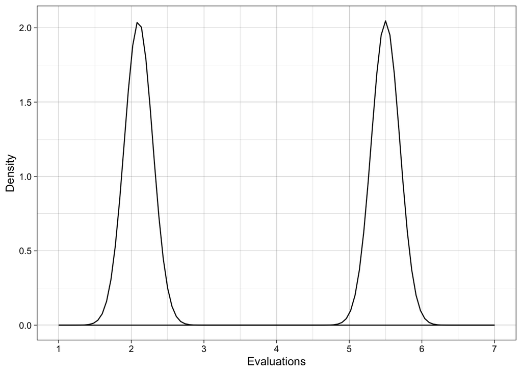

```r
M1 <- 5.5
M2 <- 2.1
SD <- 0.1949541

ggplot(data.frame(x = c(1, 7)), aes(x = x)) +
  stat_function(fun = dnorm, args = list(mean = M1, sd = SD)) + # chocolate
  stat_function(fun = dnorm, args = list(mean = M2, sd = SD)) + # poop
  scale_x_continuous(limits = c(1, 7), breaks = scales::pretty_breaks()) +
  xlab("Evaluations") +
  ylab("Density") +
  theme_linedraw()
```

- Estimated SDs imply quite a narrow normal distribution data generating signal. Perhaps this is due to the averaging of scores across the 5 adjectives. Or, it could possibly be a reporting error. Perhaps we could ask for the data from the original authors?